# Reproducible Research: Peer Assessment 1

1. This analysis uses `plyr` and `ggplot2` packages
2. It uses the [Activity monitoring data](https://d396qusza40orc.cloudfront.net/repdata%2Fdata%2Factivity.zip), which is expected to be located in the working directory.

```r
library(plyr)
library(ggplot2)
```

## 1. Loading and preprocessing the data

First we unzip the archive and load the data, and then perform some prepocessing:

- The `date` variable is transformed into `Date` format.
- The `interval` variable is transformed into a `factor`.

The reason for turning `interval` to `factor` format is that the 5-minute intervals are coded as hour number plus the 5 minutes. In this way the interval starting, for example, at midnight, is coded as 0, the one starting at 00:05 is coded as 5, and so on with 5-minute increments. However the interval starting at 00:55 will be 55, but the next one, starting at 01:00 is coded as 100. Thus, if the intervals are treated as integers, at the beginning of each new hour there is a sort of a jump, an increment of 45 instead of 5.

Later in the analysis we will be inspecting daily activity patterns on plots and I would like to have continuous plots without these odd jumps at the start of each hour. Therefor **I am going to treat the interval codes as factors for the purpose of this research.**

```r
unzip("activity.zip")
activity <- read.csv("activity.csv", stringsAsFactors = F)
activity$date <- as.Date(activity$date)
activity$interval <- as.factor(activity$interval)
```

## 2. What is mean total number of steps taken per day?

We will first use the `ddply` function from the `plyr` package to create a summary dataframe `activityTotal` which will contain the sum of steps for each day. We will ignore the `NA` values for this part of the analysis (i.e. consider them to equal zero).

Afterward we will plot a histogram of this summary dataframe with the `ggplot` function.

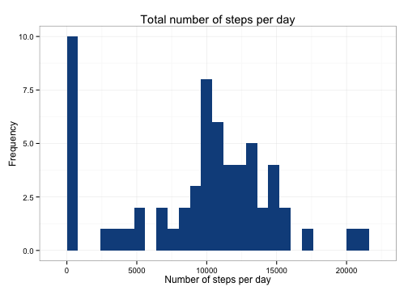

```r
activityTotal <- ddply(activity, .(date), summarise, stepsSum = sum(steps, na.rm = T))
ggplot(activityTotal, aes(x = stepsSum)) + geom_histogram(fill = "dodgerblue4",
    binwidth = 800) + xlab("Number of steps per day") + ylab("Frequency") +
    ggtitle("Total number of steps per day") + theme_bw()
```

Using this summary dataframe we can calculate the **mean** total number of steps taken per day:

```r
mean(activityTotal$stepsSum)
```

```
## [1] 9354
```

And the **median** total number of steps taken per day:

```r
median(activityTotal$stepsSum)
```

```
## [1] 10395
```

## 3. What is the average daily activity pattern?

We will make another summary dataframe, `activityAvg` which will contain the mean number of steps for each interval across all days.

We will then make a time series plot with this new dataframe. Since the `interval` variable had been converted to `factor`, by default `ggplot` will show all the 288 of its levels on the x-axis. Having 288 ticks is neither pretty nor convenient, so we will adjust the appearence of the x-axis manually and only display the ticks at the beginning of each hour, reducing their number to 24.

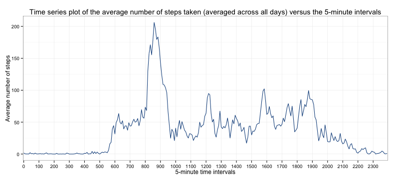

```r
activityAvg <- ddply(activity, .(interval), summarize, stepsAvg = mean(steps,
    na.rm = T))
ggplot(activityAvg, aes(x = interval, y = stepsAvg, group = 1)) + geom_line(color = "dodgerblue4") +
    scale_x_discrete(breaks = as.character(seq(0, 2300, 100))) + xlab("5-minute time intervals") +
    ylab("Average number of steps") + ggtitle("Time series plot of the average number of steps taken (averaged across all days) versus the 5-minute intervals") +
    theme_bw()
```

### 5-minute inerval with the maximum average number of steps

We can now find out which interval contains the maximum average number of steps.

```r
activityAvg$interval[activityAvg$stepsAvg == max(activityAvg$stepsAvg)]
```

```
## [1] 835
## 288 Levels: 0 5 10 15 20 25 30 35 40 45 50 55 100 105 110 115 120 ... 2355
```

It appears that the 5-minute interval that, on average, contains the maximum number of steps is **`835`**. A morning jog perhaps?

## 4. Imputing missing values

First we will calculate the number of rows containing `NA` values.

```r
nrow(activity[is.na(activity$steps), ])
```

```
## [1] 2304
```

There is 2304 rows with `NA` in them that we need to fill.

### Strategy for imputing missing data

Since we already have the mean number of steps for each interval calculated and stored in the `activityAvg` dataframe, we will use this data to fill the missing values.

We will extract the `NA` values together with their dates and intervals into a separate dataframe `stepsNA`. Then we will run a loop replacing the `NA` values with the average value for the corresponding 5-minute interval from `activityAvg`.

After that we will make a copy of our main dataframe `activity` and fill the missing values from `stepsNA`, obtaining a dataframe `activityImpute` which will have no missing values.

```r
stepsNA <- activity[is.na(activity$steps), ]
for (i in 1:nrow(activityAvg)) {
    interval <- activityAvg$interval[i]
    stepsNA$steps[stepsNA$interval == interval] <- activityAvg$stepsAvg[i]
}
activityImpute <- activity
activityImpute$steps[is.na(activityImpute$steps)] <- stepsNA$steps
```

### Histogram after filling in missing values

We now have a new dataframe `activityImpute` with missing values replaced by the average number of steps for the corresponding interval.

We will now make a summary dataframe form it and then create a histogram from this new dataframe.

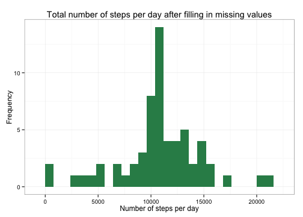

```r
actvImpTotal <- ddply(activityImpute, .(date), summarise, stepsSum = sum(steps))
ggplot(actvImpTotal, aes(x = stepsSum)) + geom_histogram(fill = "seagreen",
    binwidth = 800) + xlab("Number of steps per day") + ylab("Frequency") +
    ggtitle("Total number of steps per day after filling in missing values") +
    theme_bw()
```

### Mean and median after filling in missing values

**Mean** number of steps per day after filling in missing values:

```r
mean(actvImpTotal$stepsSum)
```

```
## [1] 10766
```

**Median** number of steps per day after filling in missing values:

```r
median(actvImpTotal$stepsSum)
```

```
## [1] 10766
```

We can observe that after filling in missing values the total number of steps per day had increased on average. Furthermore, the mean and the median are now equal.

## 5. Are there differences in activity patterns between weekdays and weekends?

We will add a new 2-level factor variable `weekday` to the `activityImpute` dataframe which will indicate whether the day is a weekend or a weekday.

```r
activityImpute$weekday[weekdays(activityImpute$date) == "Sunday" | weekdays(activityImpute$date) ==
    "Saturday"] <- "weekend"
activityImpute$weekday[is.na(activityImpute$weekday)] <- "weekday"
activityImpute$weekday <- factor(activityImpute$weekday)
```

Then we will make a new summary dataframe `actvDays` which will contain the average number of steps for each interval separately for weekends and weekdays, and then make a 2-panel plot of the resulting data.

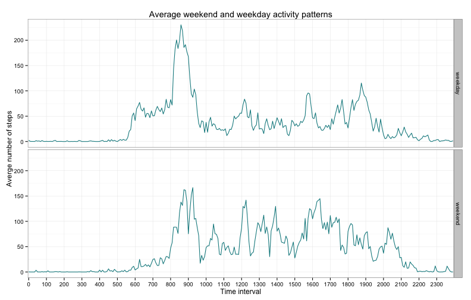

```r
actvDays <- ddply(activityImpute, .(interval, weekday), summarise, stepsAvg = mean(steps))
ggplot(actvDays, aes(x = interval, y = stepsAvg, group = 1)) + facet_grid(weekday ~
    .) + geom_line(color = "turquoise4") + scale_x_discrete(breaks = as.character(seq(0,
    2300, 100))) + xlab("Time interval") + ylab("Averge number of steps") +
    ggtitle("Average weekend and weekday activity patterns") + theme_bw()
```

We can see that the daily activity pattern is indeed different for weekdays and weekends.